# CourseMatch Metrics - Spring 2018

Data Processing for Google Sheet

2017-11-06

## 0.1 tl;dr

1. This notebook documents how we built the [Google Sheet](https://docs.google.com/a/wharton.upenn.edu/spreadsheets/d/1kFKaK7KXlvA3zUTQvFvwZNkc7F5iZ51rKo9lC3AcXwY/edit?usp=sharing) with course and instructor evaluations and clearing prices
2. It’s basically a replica of [the previous how-we-built-this](http://bit.ly/coursematch_howwebuilt)
3. There some basic exploratory plots at the end

# 1 Disclaimer

**Course Evaluations have been shown to be worthless**

Read:

1. Academic Paper: [*Meta-analysis of faculty’s teaching effectiveness: Student evaluation of teaching ratings and student learning are not related*](http://www.sciencedirect.com/science/article/pii/S0191491X16300323)
2. Slate Article: [*Student Evaluations of College Professors are Biased and Worthless*](http://www.slate.com/articles/life/education/2014/04/student_evaluations_of_college_professors_are_biased_and_worthless.html)

We put this together because Analytics Club member like this and we are interested to see what flawed data shows us. But remember:

[figure not shown]

```r
knitr::include_graphics(paste0(viz_path, "gonna_have_a_bad_time.jpg"))
```

# 2 Data Acquisition

| Data | Description | Source |
| --- | --- | --- |
| CourseMatch Sections | Actual sections we can place utility on | Download html from CourseMatch and extract the sections from the table |
| Course Information | Details such as time, number of CUs, professor, etc. | Download html from CourseMatch and extract the sections from the table |
| Course Evaluations | Couse evaluations from Spring 2016 to Fall 2017 (only Q1) | Export from Spike |
| Clearing Prices | Historical price of sections | Combined xlsx files from mba-inside.wharton.upenn.com |

## 2.1 CourseMatch Sections

To get all sections listed in CourseMatch, we extract the table from the html. Some courses are cross-listed and we create a column to include the other sections a course can be listed as.

```r
# List of sections available for selection within CourseMatch
coursematch_sections <-
  read_html(paste0(data_path, "Course Match.html")) %>%
  html_node(xpath = '//*[@id="preferences-table"]') %>%
  html_table(header = TRUE, trim = TRUE) %>%
  repair_names() %>%
  as_tibble() %>%
  select(1) %>%
  rename_at(vars(contains("Dept")), funs(paste0("Course_Multiple"))) %>%
  mutate(Section = str_extract_all(Course_Multiple, "[A-Z]{4}[0-9]{6}")) %>%
  unnest() %>%
  mutate(cross_listed_as = str_replace(Course_Multiple, Section, "")) %>%
  mutate(cross_listed_as = if_else(cross_listed_as == "", NA_character_, cross_listed_as)) %>%
  distinct(Section, cross_listed_as) %>%
  rowwise() %>%
  mutate(cross_listed_as = if_else(cross_listed_as == "", NA_character_,
                                   paste0(str_extract_all(cross_listed_as,
                          "[A-Z]{4}[0-9]{6}", simplify = TRUE), collapse = ","))) %>%
  ungroup()
```

| Section | cross_listed_as |
| --- | --- |
| ACCT613001 | NA |
| ACCT613002 | NA |
| ACCT706001 | NA |
| ACCT706002 | NA |
| ACCT742401 | NA |
| ACCT742402 | NA |
| ACCT742403 | NA |
| ACCT747001 | NA |
| ACCT747002 | NA |
| ACCT747003 | NA |

[output cut: 339 more lines]

## 2.2 Course Information

```r
spring_2018_courses <-
  readxl::read_excel(paste0(data_path, "export_courses.xls")) #%>%
  # For some reason, Corporate Restucturing and Distress Investing is listed as
  # FNCE891401 on Spike but FNCE891001 on CourseMatch - fixing this so
  # that everything matches
  # mutate(Section = str_replace(Section, "FNCE891401","FNCE891001"))
```

| Section | Title | Instructor | Max | Status | CU | Dates | Day(s) | Location | Course Quality | Instructor Quality |
| --- | --- | --- | --- | --- | --- | --- | --- | --- | --- | --- |
| ACCT101001 | PRINCIPLES OF ACCOUNTING | Zhou, Shuang | 70 | O | 1.00 | 01/10/2018 - 04/25/2018 | MW 9:00AM \n\t\t\t\t\t\t\t- 10:30AM | \n\t\t\t\t\tTBA \n | 2.32 | 2.93 |
| ACCT101002 | PRINCIPLES OF ACCOUNTING | Zhou, Shuang | 70 | O | 1.00 | 01/10/2018 - 04/25/2018 | MW 10:30AM \n\t\t\t\t\t\t\t- 12:00PM | \n\t\t\t\t\tTBA \n | 2.32 | 2.93 |
| ACCT101003 | PRINCIPLES OF ACCOUNTING | Zhou, Shuang | 70 | O | 1.00 | 01/10/2018 - 04/25/2018 | MW 12:00PM \n\t\t\t\t\t\t\t- 1:30PM | \n\t\t\t\t\tTBA \n | 2.32 | 2.93 |
| ACCT101201 | RECITATION | NA | 35 | O | 0.00 | 01/10/2018 - 04/25/2018 | F 10:00AM \n\t\t\t\t\t\t\t- 11:00AM | \n\t\t\t\t\tTBA \n | 0.00 | 0.00 |
| ACCT101202 | RECITATION | NA | 35 | O | 0.00 | 01/10/2018 - 04/25/2018 | F 11:00AM \n\t\t\t\t\t\t\t- 12:00PM | \n\t\t\t\t\tTBA \n | 0.00 | 0.00 |
| ACCT101203 | RECITATION | NA | 35 | O | 0.00 | 01/10/2018 - 04/25/2018 | F 11:00AM \n\t\t\t\t\t\t\t- 12:00PM | \n\t\t\t\t\tTBA \n | 0.00 | 0.00 |
| ACCT101204 | RECITATION | NA | 35 | O | 0.00 | 01/10/2018 - 04/25/2018 | F 12:00PM \n\t\t\t\t\t\t\t- 1:00PM | \n\t\t\t\t\tTBA \n | 0.00 | 0.00 |
| ACCT101205 | RECITATION | NA | 35 | O | 0.00 | 01/10/2018 - 04/25/2018 | F 12:00PM \n\t\t\t\t\t\t\t- 1:00PM | \n\t\t\t\t\tTBA \n | 0.00 | 0.00 |
| ACCT101206 | RECITATION | NA | 35 | O | 0.00 | 01/10/2018 - 04/25/2018 | F 1:00PM \n\t\t\t\t\t\t\t- 2:00PM | \n\t\t\t\t\tTBA \n | 0.00 | 0.00 |
| ACCT102001 | MANAGERIAL ACCOUNTING | Deller, Carolyn | 70 | O | 1.00 | 01/10/2018 - 04/25/2018 | MW 10:30AM \n\t\t\t\t\t\t\t- 12:00PM | \n\t\t\t\t\tTBA \n | 0.00 | 0.00 |

[output cut: 10 more lines]

## 2.3 Course Evaluations

Course evaluation comes from a [Spike export](https://spike.wharton.upenn.edu/courses/?method=export_evaluations). You need to open the Excel file and resave before it will load into R (see documented issue caused by the way this file was built by Spike).

```r
course_eval <-
  readxl::read_excel(paste0(data_path, "CourseEvaluationData.xls"), skip = 1) %>%
  filter(n() != row_number())
```

| Term | Section | Title | Instructor | Overall Quality of Instructor (0=worst 4=best) | Overall Quality of Course (0=worst 4=best) | Instructor Ability to Communicate Subject Matter (0=worst 4=best) | Instructor Ability to Stimulate Student Interest (0=worst 4=best) | Instructor Accessibility / Willingness to Discuss Course Content / Problems (0=worst 4=best) | Value of Assigned Readings (0=worst 4=best) | Learned from this Course in terms of Knowledge / Concepts / Skills / Thinking Ability (0=worst 4=best) | Rate the Difficulty of this Course (0=easiest 4=hardest) | Rate the Amount of Work Required for this Course (0=easiest 4=hardest) | Would you Recommend this Course to a Major? (4=most strongly) | Would you Recommend this Course to a Non-Major? (4=most strongly) |
| --- | --- | --- | --- | --- | --- | --- | --- | --- | --- | --- | --- | --- | --- | --- |
| 2017C | ACCT612001 | ACCELERATED FIN ACCT | Verrecchia, Robert E | 2.71 | 2.62 | 2.54 | 2.47 | 2.95 | 2.05 | 2.67 | 2.93 | 2.61 | 2.79 | 2.08 |
| 2017C | ACCT612003 | ACCELERATED FIN ACCT | Verrecchia, Robert E | 2.59 | 2.49 | 2.67 | 2.47 | 2.88 | 2.20 | 2.74 | 3.22 | 2.59 | 2.75 | 2.04 |
| 2017C | ACCT612005 | ACCELERATED FIN ACCT | Verrecchia, Robert E | 2.59 | 2.35 | 2.73 | 2.67 | 3.14 | 2.27 | 2.64 | 2.67 | 2.50 | 3.07 | 2.21 |
| 2017C | ACCT706701 | COST MANAGEMENT | Ittner, Christopher D | 3.29 | 3.03 | 3.50 | 2.78 | 3.31 | 3.33 | 3.00 | 2.43 | 2.29 | 3.04 | 2.82 |
| 2017C | BEPP305401 | RISK MANAGEMENT | Doherty, Neil A | 2.44 | 2.33 | 2.42 | 2.26 | 2.33 | 2.63 | 2.32 | 3.22 | 2.11 | 2.53 | 1.74 |
| 2017C | BEPP305402 | RISK MANAGEMENT | Doherty, Neil A | 2.81 | 2.28 | 2.63 | 2.08 | 2.92 | 2.68 | 2.58 | 2.92 | 2.16 | 2.40 | 1.40 |
| 2017C | FNCE386001 | ASP - HEDGE FUNDS | Yilmaz, Bilge | 3.06 | 2.29 | 2.93 | 2.59 | 2.26 | 2.96 | 2.04 | 0.93 | 0.89 | 2.52 | 1.56 |
| 2017C | FNCE393001 | GLOBAL MONETARY AND FINANCIAL STABILITY POLICY | Eckstein, Zvi | 3.25 | 2.94 | 3.00 | 3.06 | 3.19 | 3.20 | 3.33 | 3.06 | 2.75 | 3.07 | 2.31 |
| 2017C | FNCE751001 | FNCE OF BUYOUTS & ACQS | Yilmaz, Bilge | 2.53 | 2.18 | 2.47 | 2.52 | 2.36 | 2.29 | 2.21 | 2.17 | 1.90 | 2.70 | 2.04 |
| 2017C | FNCE751002 | FNCE OF BUYOUTS & ACQS | Yilmaz, Bilge | 2.97 | 2.83 | 2.89 | 2.17 | 2.31 | 2.93 | 2.74 | 2.41 | 2.15 | 3.11 | 2.26 |

[output cut: 10 more lines]

## 2.4 Clearing Prices

Clearing price data comes the **public** [MBA Inside website](https://mba-inside.wharton.upenn.edu/course-match/). We loop over the page, download, and combine each of the xlsx files.

```r
base_url <- "https://mba-inside.wharton.upenn.edu/course-match/"

# Read in the base url, find all the links, extract
# the ones that contain xlsx and then download each
# one giving it the proper name
if (params$external_queries) {
  read_html(base_url) %>%
    html_nodes('a') %>%
    html_attr("href") %>%
    as_tibble() %>%
    filter(str_detect(value, "xlsx")) %>%
    mutate(file_name = basename(value)) %>%
    mutate(a = walk2(value, paste0(data_path, "clearing_prices/", file_name), download.file, mode = "wb"))
}

# Function to load each xlsx file of clearing prices
# Need to have a switch because the Fall 2013 file
# contains an extra row at the top
fn_load_clearing_price_xlsx <- function(file_name) {
  if (str_detect(file_name, "13")) {
    readxl::read_excel(file_name, skip = 1)
  } else {
    readxl::read_excel(file_name, skip = 0)
  }
}

# Function to rename the columns that
# look like 'section' and 'price' to Section
# and Price so that they can be binded
fn_rename_at <- function(df, string) {
  df %>%
    rename_at(vars(matches(string)), funs(paste0(string)))
}

# Load and coalesce each of the clearing price
# Excel files
clearing_prices <-
  list.files(paste0(data_path, "clearing_prices/"), full.names = TRUE) %>%
  map(fn_load_clearing_price_xlsx) %>%
  map(select, matches("Section|Price")) %>%
  map(fn_rename_at, string = "Section") %>%
  map(fn_rename_at, string = "Price") %>%
  bind_rows() %>%
  mutate(Course = str_sub(Section, 1, 7)) %>%
  select(Course, Section, Price)
```

| Course | Section | Price |
| --- | --- | --- |
| ACCT611 | ACCT611001 | 0.00 |
| ACCT611 | ACCT611002 | 0.00 |
| ACCT611 | ACCT611003 | 1381.58 |
| ACCT612 | ACCT612001 | 0.00 |
| ACCT612 | ACCT612003 | 0.00 |
| ACCT612 | ACCT612005 | 0.00 |
| ACCT613 | ACCT613001 | 1251.36 |
| ACCT613 | ACCT613003 | 1765.40 |
| ACCT613 | ACCT613005 | 1410.22 |
| ACCT613 | ACCT613007 | 0.00 |

[output cut: 990 more lines]

# 3 Data Cleaning

After acquiring data from the four data sources we need to do some combining and cleaning.

```r
spring_2018 <-
  spring_2018_courses %>%
  select(-Max, -Status) %>%
  distinct() %>%
  mutate(Section = strsplit(as.character(Section), " / ")) %>%
  unnest(Section) %>%
  select(Section, everything()) %>%
  inner_join(coursematch_sections, by = "Section") %>%
  mutate(title_length = length(Title)) %>%
  arrange(Section, desc(title_length)) %>%
  group_by(Section) %>%
  filter(row_number() == 1) %>%
  ungroup() %>%
  mutate(
    Course = str_sub(Section, 1, 7)
    , Section = str_sub(Section, 8, 10)
    , CU = as.numeric(CU)
  ) %>%
  select(Course, Section, Title, Instructor, CU, Dates, `Day(s)`, cross_listed_as) %>%
  separate(Dates, c("start_date", "end_date"), sep = "-") %>%
  mutate(
      start_date = lubridate::mdy(start_date)
    , Days = stringr::str_extract(`Day(s)`, "^([\\w]+)")
    , Quarter = if_else(CU == 1, "Full", if_else(lubridate::month(start_date) == 8, "Q1", "Q2"))
    , start_time = stringr::str_extract(`Day(s)`, "(?:\\S+){2}(\\S+)")
    , end_time = str_trim(stringr::str_extract(`Day(s)`, "\\s(\\S+)$"))
    , Title = str_to_title(Title)
  ) %>%
  select(-start_date, -end_date, -`Day(s)`) %>%
  filter(str_sub(Course, 1, 4) != "WHCP")
```

We first create a table that contains all the sections that are available on CourseMatch and the useful information about the section: title, instructor, CU, quarter, time, etc.

| 10 sample rows from of cleaned information about the courses listed in CourseMatch Course | 10 sample rows from of cleaned information about the courses listed in CourseMatch Section | 10 sample rows from of cleaned information about the courses listed in CourseMatch Title | 10 sample rows from of cleaned information about the courses listed in CourseMatch Instructor | 10 sample rows from of cleaned information about the courses listed in CourseMatch CU | 10 sample rows from of cleaned information about the courses listed in CourseMatch Days | 10 sample rows from of cleaned information about the courses listed in CourseMatch Quarter | 10 sample rows from of cleaned information about the courses listed in CourseMatch Start Time | 10 sample rows from of cleaned information about the courses listed in CourseMatch End Time |
| --- | --- | --- | --- | --- | --- | --- | --- | --- |
| MGMT811 | 002 | Entrep Through Acquis.: Entrepreneurship Through Acquisitions | Chalfin, Robert | 0.5 | MW | Q2 | 3:00PM | 4:30PM |
| ACCT747 | 003 | Fin Statement & Dis Ana | Bushee, Brian | 1 | MW | Full | 1:30PM | 3:00PM |
| FNCE611 | 002 | Corporate Finance | Dieckmann, Stephan / Kaufold, Howard | 1 | MW | Full | 10:30AM | 12:00PM |
| OIDD691 | 412 | Negotiations | Arnett, Rachel | 1 | TR | Full | 3:00PM | 4:30PM |
| MGMT802 | 001 | Innov, Chg And Ent | Mollick, Ethan | 0.5 | MW | Q2 | 3:00PM | 4:30PM |
| LGST612 | 014 | Responsibility In Bus. | Machlis, Roger / Gentin, Pierre | 0.5 | W | Q2 | 3:00PM | 6:00PM |
| LGST642 | 001 | Big Data, Big Resp. | Werbach, Kevin | 0.5 | TR | Q2 | 9:00AM | 10:30AM |
| BEPP770 | 401 | Intro To Business Econom | Seim, Katja | 1 | TR | Full | 12:00PM | 1:30PM |
| OIDD612 | 004 | Business Analytics | Tsoukalas, Gerry | 0.5 | MW | Q2 | 1:30PM | 3:00PM |
| OIDD691 | 408 | Negotiations | Light, Sarah | 1 | T | Full | 3:00PM | 6:00PM |

```r
tbl_questions <- tribble(
   ~question_type, ~question, ~question_abbr
   , 'Course', 'Overall Quality of Course (0=worst 4=best)', 'Course Quality'
   , 'Course', 'Value of Assigned Readings (0=worst 4=best)', 'Value of Assigned Readings'
   , 'Course', 'Learned from this Course in terms of Knowledge / Concepts / Skills / Thinking Ability (0=worst 4=best)', 'Amount Learned'
   , 'Course', 'Rate the Difficulty of this Course (0=easiest 4=hardest)', 'Difficulty'
   , 'Course', 'Rate the Amount of Work Required for this Course (0=easiest 4=hardest)', 'Amount of Work Required'
   , 'Course', 'Would you Recommend this Course to a Major? (4=most strongly)', 'Recommend to Major?'
   , 'Course', 'Would you Recommend this Course to a Non-Major? (4=most strongly)', 'Recommend to Non-Major'
   , 'Instructor', 'Overall Quality of Instructor (0=worst 4=best)', 'Instructor Quality'
   , 'Instructor', 'Instructor Ability to Communicate Subject Matter (0=worst 4=best)', 'Ability to Communicate Subject Matter'
   , 'Instructor',  'Instructor Ability to Stimulate Student Interest (0=worst 4=best)', 'Ability to Stimulate Interest'
   , 'Instructor', 'Instructor Accessibility / Willingness to Discuss Course Content / Problems (0=worst 4=best)', 'Instructor Accessibility'
) %>%
  mutate(
    question_type = fct_inorder(question_type)
    , question_abbr = fct_inorder(question_abbr)
  )
```

```r
tbl_course_lookup <-
  tribble(
    ~evaluated_course, ~coursematch_course,
    #'ACCT208', 'ACCT718',
    'BEPP201',  'BEPP770', # Taught Spring 2018
    'BEPP305',  'BEPP805', # Taught Spring 2018
    #'STAT451', 'BEPP851',
    #'STAT453', 'BEPP853',
    #'REAL721', 'FNCE721',
    #'OIDD693', 'LGST693',
    #'LGST809', 'MGMT815',
    #'OIDD415', 'OIDD515',
    #'STAT470', 'STAT770',
    #'STAT451', 'STAT851',
    'STAT453',  'STAT853',
    NA_character_, 'MGMT833', # Taught Spring 2018
    #NA_character_, 'LGST641',
    'OIDD691', 'MGMT691',  # Negotiations
    'LGST806', 'MGMT691',  # Negotiations
    'BEPP289', 'BEPP789',  # NATIONS, POL AND MARKETS
    'OIDD261', 'BEPP761',  # Risk Analysis and Environmental Management
    'LGST202', 'LGST802',  # Law of Corp Mgmt & Fnce
    'LGST220', 'LGST820',  # Int'l Bus Ethics
    'LGST215', 'LGST815',  # Envt'l Mgmt Law & Pol
    'MKTG224', 'MKTG724',  # Advertisting Management
    'OIDD397', 'OIDD697',  # Retail Supply Chain Mgmt
    'OIDD261', 'OIDD761',  # Risk Analy & Evn Mgmt
    'REAL215', 'REAL724',  # Urban Real Estate Econ
    'MKTG212', 'MKTG712'   # Data and Analysis for Marketing Decisions
  )
```

```r
# coursematch_sections %>% filter(!is.na(cross_listed_as)) %>% mutate(Course = str_sub(Section, 1, 7), CL = str_sub(cross_listed_as, 1, 7)) %>% distinct(Course, CL) %>% View()
cross_listed_course <-
  tribble(
      ~coursematch, ~evaluated_as
      , "BEPP708", "REAL708" # Housing Markets
      , "OIDD763", "BEPP763" # Energy Markets and Policy
      , "FNCE721", "REAL721" # Real Estate Investments
      , "LGST692", "OIDD692" # Advanced Topics in Negotiations
      , "LGST804", "REAL804" # Real Estate Law
      , "LGST806", "MGMT691" # Negotiations
      , "MGMT815", "LGST809" # Sports Business Mgmt
      , "MGMT692", "OIDD692" # Advanced Topics in Negotiations
      , "STAT776", "MKTG776" # Applied Probablistic Models in Marketing
      , "OIDD691", "MGMT691" # Negotiations
      , "MGMT690", "OIDD690" # Managerial Decisn Making -- Not Taught Spring 2018
      , "LGST693", "OIDD693" # Influence                -- Not Taught Spring 2018
    )
```

Then we clean the course evaluation data so that it can be aggregated. Here are 10 sample rows:

```r
course_eval_cleaned <-
  course_eval %>%
  gather(question, value, -Term, -Section, -Title, -Instructor) %>%
  left_join(tbl_questions, by = 'question') %>%
  select(-question) %>%
  mutate(
      Year = str_sub(Term, 1,4)
    , Course = str_sub(Section, 1, 7)
  ) %>%
  left_join(tbl_course_lookup, by = c('Course' = 'evaluated_course')) %>%
  mutate(Course = if_else(is.na(coursematch_course), Course, coursematch_course)) %>%
  mutate(
    Course_Num = str_sub(Course, 5, 7)
    , Dept = str_sub(Course, 1, 4)
  ) %>%
  select(Year, Dept, Course_Num, Course, Section, Title, Instructor, question_type, question_abbr, value) %>%
  filter((Course_Num >= 600 & Course_Num < 900) & str_sub(Course, 1, 4) != "WHCP")
```

| 10 sample rows from the tidied course evaluation data Year | 10 sample rows from the tidied course evaluation data Dept | 10 sample rows from the tidied course evaluation data Course Number | 10 sample rows from the tidied course evaluation data Course | 10 sample rows from the tidied course evaluation data Section | 10 sample rows from the tidied course evaluation data Title | 10 sample rows from the tidied course evaluation data Instructor | 10 sample rows from the tidied course evaluation data Question Type | 10 sample rows from the tidied course evaluation data Question | 10 sample rows from the tidied course evaluation data Value |
| --- | --- | --- | --- | --- | --- | --- | --- | --- | --- |
| 2017 | ACCT | 613 | ACCT613 | ACCT613001 | FIN AND MNGL ACCT | Radhakrishna, Radha | Course | Value of Assigned Readings | 2.65 |
| 2017 | REAL | 721 | REAL721 | REAL721405 | REAL ESTATE INVESTMENTS | Sinai, Todd | Course | Difficulty | 3.28 |
| 2017 | FNCE | 615 | FNCE615 | FNCE615006 | MACROECONOMICS (HALF CU) | Gomes, Joao | Course | Course Quality | 1.76 |
| 2017 | STAT | 722 | STAT722 | STAT722403 | PREDICTIVE ANALYTICS | Kapelner, Adam | Course | Recommend to Non-Major | 0.77 |
| 2017 | MGMT | 612 | MGMT612 | MGMT612001 | MANAGING EMERG ENTRPRSE: Managing the Emerging Enterprise | Hernandez, Exequiel | Instructor | Ability to Communicate Subject Matter | 3.4 |
| 2016 | FNCE | 750 | FNCE750 | FNCE750001 | VENT CAP & FNCE INNOVAT | Taylor, Luke | Course | Value of Assigned Readings | 3.49 |
| 2017 | MGMT | 611 | MGMT611 | MGMT611003 | MANAGING EST ENTERPRISE: Managing the Established Enterprise | Zhao, Minyuan | Course | Difficulty | 2.12 |
| 2017 | MGMT | 811 | MGMT811 | MGMT811701 | ENTREP THROUGH ACQUIS. | Chalfin, Robert | Course | Amount Learned | 2.84 |
| 2017 | OIDD | 612 | OIDD612 | OIDD612003 | BUSINESS ANALYTICS | Iancu, Dan | Course | Amount Learned | 3.03 |
| 2017 | OIDD | 613 | OIDD613 | OIDD613001 | INFO & BUS TRANSFRM: ONLINE INNOVATION: NEW PATTERNS OF POWER AND PROFIT | Clemons, Eric K | Instructor | Ability to Communicate Subject Matter | 1.08 |

# 4 Summaries for Google Sheet

With the course evaluation that Wharton provides we can present that data at two levels of detail:

1. **Course View**: Aggregate the reviews for all sections a course was taught
2. **Instructor View**: Aggregate the reviews for all sections an instructor has taught

We also create both tables and “benchmark” that uses all historical data (not just the courses that will be taught in Spring 2018).

## 4.1 Course View

```r
course_metrics <-
  spring_2018 %>%
  left_join(cross_listed_course, by = c('Course' = 'coursematch')) %>%
  mutate(evaluated_as = if_else(is.na(evaluated_as), Course, evaluated_as)) %>%
  left_join(
    course_eval_cleaned %>%
    filter(question_type == "Course") %>%
    group_by(Course, question_abbr) %>%
    summarise(
      value = mean(value)
      , sections_evaluated = n()
    ) %>%
    spread(question_abbr, value)
    , by = c('evaluated_as' = 'Course')
  ) %>%
  left_join(
    clearing_prices %>%
      filter(str_sub(Course, 1, 4) != "WHCP") %>%
      mutate(Course = str_replace(Course, "OPIM", "OIDD")) %>%
      left_join(cross_listed_course, by = c('Course' = 'coursematch')) %>%
      mutate(evaluated_as = if_else(is.na(evaluated_as), Course, evaluated_as)) %>%
      group_by(evaluated_as) %>%
      summarise(clearing_price = mean(Price)) %>%
      ungroup() %>%
      mutate(percentile = percent_rank(clearing_price))
    , by = c("evaluated_as")
  ) %>%
  select(-evaluated_as) %>%
  select(-one_of('cross_listed_as'), one_of('cross_listed_as'))
```

```r
course_benchmark <-
  course_eval_cleaned %>%
    filter(question_type == "Course") %>%
    group_by(question_abbr) %>%
    summarise(
      value = mean(value)
      , sections_evaluated = n()
    ) %>%
    spread(question_abbr, value) %>%
    bind_cols(
      clearing_prices %>%
      filter(str_sub(Course, 1, 4) != "WHCP") %>%
      summarise(clearing_price = mean(Price))
    )
```

## 4.2 Instructor View

```r
instructor_metrics <-
  spring_2018 %>%
  mutate(instructors = strsplit(Instructor, "/")) %>%
  unnest(instructors) %>%
  mutate(instructors = str_trim(instructors)) %>%
  filter(!(is.na(instructors) | instructors == "")) %>%
  distinct(instructors) %>%
  left_join(
    course_eval_cleaned %>%
    filter(question_type == "Instructor") %>%
    group_by(Instructor, question_abbr) %>%
    summarise(
        value = mean(value)
        , sections_evaluated = n()
    ) %>%
    spread(question_abbr, value)
  , by = c('instructors' = 'Instructor')
  ) %>%
  arrange(instructors)
```

```r
instructor_benchmark <-
  course_eval_cleaned %>%
    filter(question_type == "Instructor") %>%
    group_by(question_abbr) %>%
    summarise(
      value = mean(value)
      , sections_evaluated = n()
    ) %>%
    spread(question_abbr, value)
```

## 4.3 Export to Google Sheet

We then use the [googlesheets](https://cran.r-project.org/web/packages/googlesheets/) package to add them to the [Google Sheet](https://docs.google.com/a/wharton.upenn.edu/spreadsheets/d/1kFKaK7KXlvA3zUTQvFvwZNkc7F5iZ51rKo9lC3AcXwY/edit?usp=sharing)

[interactive chart not shown]

```r
if (params$external_queries) {
  gs <- gs_title("Analytics Club - CourseMatch Spring 2018 (File → Make a copy)")

  # Course View tab
  gs %>% gs_edit_cells(ws = "Course View", input = course_benchmark, anchor = "K3", col_names = FALSE)
  gs %>% gs_edit_cells(ws = "Course View", input = course_metrics, anchor = "B4", col_names = FALSE)

  # Instructor View tab
  gs %>% gs_edit_cells(ws = "Instructor View", input = instructor_benchmark, anchor = "C3", col_names = FALSE)
  gs %>% gs_edit_cells(ws = "Instructor View", input = instructor_metrics, anchor = "B4", col_names = FALSE)
}
```

# 5 Exploratory Analysis

We figured we’d explore the data bit. Here are a few plots we built. To a do a real analysis, we would need response level data. In practice, we would want to built to confidence intervals to detect where the differences in response are significant before making any comparative statements. We only have the point estimate (mean) and not the standard error so we cannot do anything more sophisicated.

## 5.1 Evaluations by Department

```r
course_summary <-
  course_eval_cleaned %>%
  group_by(Dept, Course, question_type, question_abbr) %>%
  summarise(
    value = mean(value)
    , sections_evaluated = n()
  )
```

```r
dept_summary <-
  course_summary %>%
  group_by(question_abbr) %>%
  mutate(question_avg = sum(value * sections_evaluated)/ sum(sections_evaluated)) %>%
  ungroup() %>%
  group_by(Dept, question_type, question_abbr, question_avg) %>%
  summarise(wght_avg = sum(value * sections_evaluated)/ sum(sections_evaluated)) %>%
  ungroup()
```

```r
fn_spline_plot <- function(data) {
  p <-
  data %>%
  ggplot(aes(x = fct_reorder(Dept, wght_avg) , y = wght_avg, ymin = 1, ymax = wght_avg)) +
  facet_wrap(~question_abbr, scale = 'free_x') +
  geom_hline(data = . %>% select(-wght_avg) %>% distinct(), aes(yintercept = question_avg),
             linetype = "dashed", colour =  wharton_col[['wharton_red']]) +
  geom_linerange(colour = wharton_col[['wharton_blue']]) +
  coord_flip() +
  labs(x = NULL, y = NULL) +
  theme(panel.grid = element_blank()) +
  scale_y_continuous(expand = c(0.0, 0.01), limits = c(1, 3.5)) +
  geom_point(colour = wharton_col[['wharton_blue']]) +
  geom_text(aes(label = scales::comma(wght_avg, digits = 3)), hjust = -0.15) +
  geom_text(data = . %>% filter(wght_avg == min(wght_avg)),
            aes(x = Dept, y = question_avg,
                label = paste0("Avg: ",  scales::comma(wght_avg, digits = 2))), hjust = -0.05,
            colour =  wharton_col[['wharton_red']])
  return(ggplotGrob(p))
}
```

```r
dept_plots <-
  dept_summary %>%
  mutate(question = question_abbr) %>%
  nest(-question_type, -question) %>%
  mutate(plot = map(data, fn_spline_plot))
```

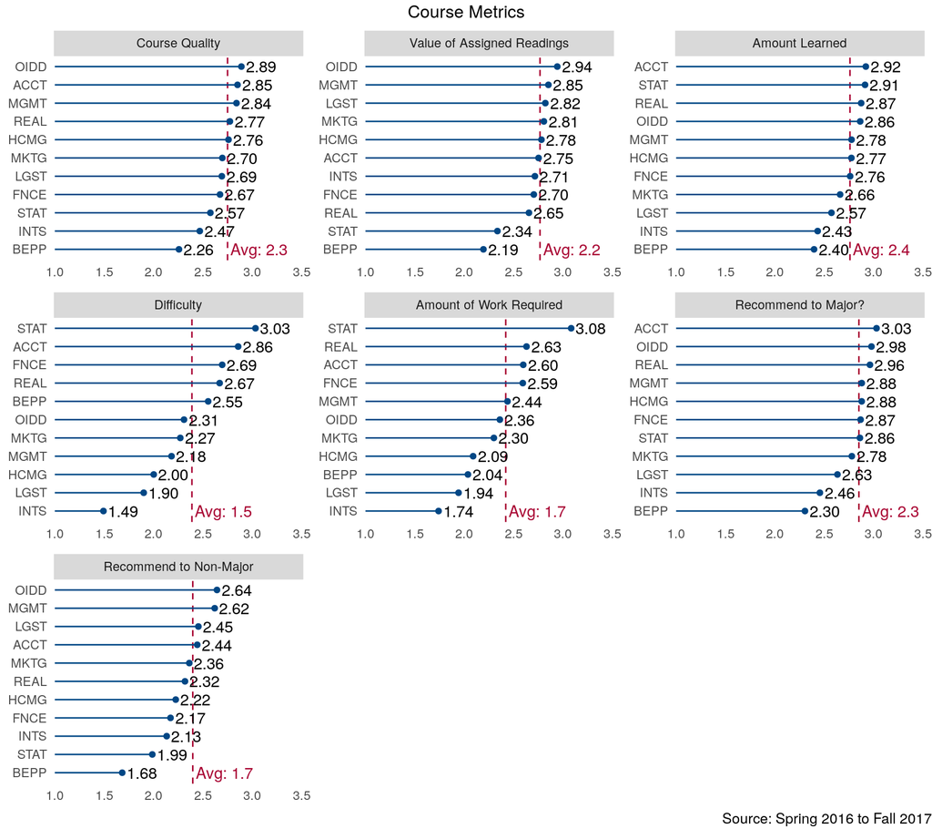

```r
dept_plots %>%
  filter(question_type == "Course") %>%
  pull(plot) %>%
  grid.arrange(grobs = ., top = "Course Metrics", bottom = textGrob("Source: Spring 2016 to Fall 2017",
                               gp = gpar(fontsize=10),
                               hjust=1, x=1))
```

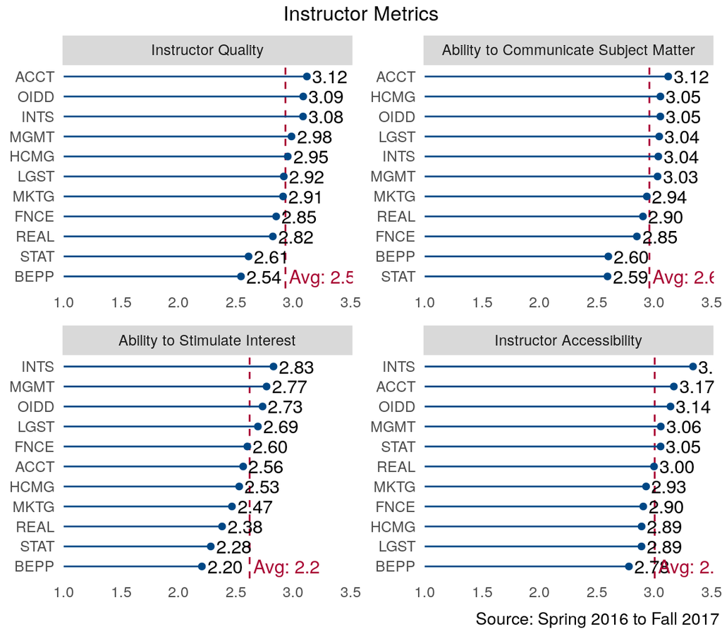

```r
dept_plots %>%
  filter(question_type == "Instructor") %>%
  pull(plot) %>%
  grid.arrange(grobs = ., top = "Instructor Metrics",
               bottom = textGrob("Source: Spring 2016 to Fall 2017",
                               gp = gpar(fontsize=10),
                               hjust=1.01, x=1))
```

## 5.2 Which course is the “best bang for your utility”?

The plot below help answer what has historically been the best value (course quality) for your utility. There are many courses that have never had non-zero clearing prices.

```r
course_quality_to_price <-
  course_metrics %>%
  distinct(Course, `Course Quality`, Title, clearing_price) %>%
  mutate(title_length = length(Title)) %>%
  arrange(Course, title_length) %>%
  group_by(Course) %>%
  filter(row_number() == 1) %>%
  ungroup() %>%
  mutate(dept = str_sub(Course, 1, 4)) %>%
  rename(quality = `Course Quality`) %>%
  filter(complete.cases(.))

course_quality_to_price %>%
  hchart("scatter", hcaes(x = clearing_price, y = quality, group = dept, course = Course,
                          title = Title)) %>%
  hc_tooltip(pointFormat = "<span style=\"color:{series.color}\">{point.course}</span>:{point.title}<br/>
              Clearing Price: <b>{point.x:,.1f}</b><br/>
              Course Quality: <b>{point.y:,.2f}</b><br/>",
             shared = TRUE) %>%
  hc_xAxis(title = list(text = "Average Clearing Price")) %>%
  hc_yAxis(title = list(text = "Average Course Quality")) %>%
  hc_title(text = 'Which course is the "best bang for your utility"?') %>%
  hc_subtitle(text = "Value courses are in the top left corner") %>%
  hc_credits(enabled = TRUE, text = "Source: Spring 2016 to Fall 2017") %>%
  hc_add_theme(hc_theme_merge(
    getOption("highcharter.theme"),
    hc_theme(colors = wharton_col[c('wharton_blue','wharton_red','bay_blue','morning_yellow','college_grey',
                                    'evening_red','sunset_red','night_street','marine_grey','heritage_red')] %>% unname()))) %>%
  hc_size(height = 700)
```

[interactive chart not shown]

```r
instructor_metrics %>%
  arrange(desc(`Instructor Quality`)) %>%
  mutate(
    rnk = row_number()
    , `Instructor Quality` = formatC(`Instructor Quality`, format = 'f', digits = 2)
  ) %>%
  head(10) %>%
  select(rnk, instructors, `Instructor Quality`) %>%
  left_join(
    instructor_metrics %>%
    arrange(`Instructor Quality`) %>%
    mutate(
    rnk = row_number()
    , `Instructor Quality` = formatC(`Instructor Quality`, format = 'f', digits = 2)
    ) %>%
    head(10) %>%
    select(rnk, instructors, `Instructor Quality`)
    , by = 'rnk'
  ) %>%
  htmlTable(
    rnames = FALSE
    , caption = "Top 10 and Bottom 10 Instructors for Spring 2017"
    , align = c("clclc")
    , col.rgroup = c("none", "#F7F7F7")
    , cgroup = c("", "Top 10", "Bottom 10")
    , n.cgroup = c(1,2,2)
    , header = c("Rank", rep(c("Instructor", "Quality"), 2))
    , css.cell = "padding-left: 2em; padding-right: 2em;"
  ) #%>% htmltools::html_print()
```

[output not shown]

## 5.4 Number of Course Offerrings by Department

```r
course_metrics %>%
  mutate(dept = str_sub(Course, 1, 4)) %>%
  group_by(dept) %>%
  summarise(
    Courses = n_distinct(Course)
    , Sections = n()
  ) %>%
  gather(metric, value, -dept) %>%
  hchart("column", hcaes(x = dept, y = value, group = metric)) %>%
  hc_xAxis(title = list(text = "Department")) %>%
  hc_yAxis(title = list(text = "Count")) %>%
  hc_title(text = 'Do some department offer more coures?') %>%
  hc_subtitle(text = "MGMT and FNCE dominate in number of course offerrings") %>%
  hc_credits(enabled = TRUE, text = "Note: Cross-listing is counted for each department") %>%
  hc_add_theme(hc_theme_merge(
    getOption("highcharter.theme"),
    hc_theme(colors = wharton_col[c('wharton_blue','wharton_red')] %>% unname()))) %>%
  hc_size(height = 600)
```

[interactive chart not shown]